# Races vs tournaments

# Data

## Skill rating percentile

A total of 205 competiotrs out of 299 had a non-null skill rating. This is an integer that reflects the relative ability of a coder, as it was assessed by its past performance in previous contests. As the absolute values of the skill rating are skewed and it can be hard to interpret them (i.e, having twice as high rating does not mean that a coder is twice as able than another), we used the skill-rating percentile:
$$skill\_pc = 100 \frac{rank(rating) - 1}{\# ratings - 1}.$$
The competitors with no rating were ranked last and their skill-rating percentile was computed by breaking ties at random.

## Imputation

We matched the registration data with the responses obtained via the registration survey.

```r
random.imp <- function(x) {
  miss <- is.na(x)
  x.rand <- sample(x[!miss], replace = T)
  ifelse(is.na(x), x.rand, x)
}
races_df$educ <- factor(random.imp(races_df$educ), labels = levels(races_df$educ))
races_df$age <- factor(random.imp(races_df$age), labels = levels(races_df$age))
races_df$male <- random.imp(races_df$male)
races_df$risk <- random.imp(races_df$risk)
for (v in grep("hours", names(races_df))) {
  races_df[,v] <- random.imp(races_df[,v])
}
```

## Curation

```r
races_df$aval_time <- with(races_df, hours1 + hours2 + hours3 + hours4)
races_df$aval_time_tc <- topcode(races_df$aval_time, 80)
```

# Regressions

## Estimate prob. of entry by treatment

```r
lm.entry <- glm(100 * (nsub > 0) ~ treatment + large + center(skill_pc), data = races_df)
lm.entry1 <- update(lm.entry, ~ . + center(aval_time_tc/8) + region)
lm.entry2 <- update(lm.entry1, ~ . + I(create_year > 2010))
lm.entry3 <- update(lm.entry1, ~ . + educ)
lm.entry4 <- update(lm.entry1, ~ . + age)
lm.entry5 <- update(lm.entry1, ~ . + male)
lm.entry6 <- update(lm.entry1, ~ . + risk)
ols.entry <- lapply(objects(pattern = "lm.entry"), get)
ols.entry.interact <- lapply(ols.entry, update, formula = ~ . + treatment:large)
ols.entry.skill.interact <- lapply(ols.entry, update, formula = ~ . + treatment:center(skill_pc))
ols.entry.time.interact <- lapply(ols.entry, update, formula = ~ . + treatment:center(aval_time_tc/8))
binom.entry <- lapply(ols.entry, update, formula = nsub > 0 ~ ., family = "binomial")
binom.entry.interact <- lapply(ols.entry.interact, update, formula = nsub > 0 ~ ., family = "binomial")
```

## Regression tables

Click tabs below to see different regression tables.

### OLS

**Estimates for the Probability of Entry**

|  | 100 * (nsub > 0) |  |  |  |  |  |  |
| --- | --- | --- | --- | --- | --- | --- | --- |
|  | (1) | (2) | (3) | (4) | (5) | (6) | (7) |
| treatmentReserve | 1.0 | 1.5 | 1.8 | 0.9 | 1.1 | 1.2 | 1.5 |
|  | (6.2) | (6.1) | (6.1) | (6.2) | (6.2) | (6.1) | (6.1) |
| treatmentTournament | 6.9 | 8.3<sup>a</sup> | 8.4<sup>a</sup> | 8.3<sup>a</sup> | 8.7<sup>a</sup> | 8.2<sup>a</sup> | 8.3<sup>a</sup> |
|  | (6.2) | (6.3) | (6.3) | (6.3) | (6.3) | (6.3) | (6.3) |
| large | 0.5 | -0.5 | -0.5 | -0.2 | -0.04 | -1.1 | -0.5 |
|  | (5.1) | (5.1) | (5.1) | (5.2) | (5.2) | (5.2) | (5.1) |
| center(skill_pc) | 0.5*** | 0.5*** | 0.4*** | 0.5*** | 0.4*** | 0.4*** | 0.4*** |
|  | (0.1) | (0.1) | (0.1) | (0.1) | (0.1) | (0.1) | (0.1) |
| center(aval_time_tc/8) |  | 2.6** | 2.7** | 2.6** | 2.6** | 2.6** | 2.7** |
|  |  | (1.1) | (1.1) | (1.1) | (1.1) | (1.1) | (1.1) |
| regionAsia |  | 3.3 | 3.8 | 3.5 | 3.4 | 3.2 | 3.3 |
|  |  | (7.8) | (7.8) | (7.8) | (8.0) | (7.8) | (7.8) |
| regionEurope |  | 8.1 | 8.2 | 8.6 | 8.5 | 8.2 | 7.9 |
|  |  | (7.9) | (8.0) | (8.0) | (8.1) | (7.9) | (8.0) |
| regionOther |  | -13.3 | -11.9 | -13.9 | -13.9 | -13.1 | -13.1 |
|  |  | (13.0) | (13.1) | (13.1) | (13.1) | (13.0) | (13.0) |
| I(create_year > 2010) |  |  | -4.1 |  |  |  |  |
|  |  |  | (5.3) |  |  |  |  |
| educPhd |  |  |  | -5.7 |  |  |  |
|  |  |  |  | (10.8) |  |  |  |
| educPostgrad |  |  |  | -8.4 |  |  |  |
|  |  |  |  | (8.4) |  |  |  |
| educUndergrad |  |  |  | -2.9 |  |  |  |
|  |  |  |  | (8.4) |  |  |  |
| age18 - 24 |  |  |  |  | 10.4 |  |  |
|  |  |  |  |  | (12.4) |  |  |
| age25 - 34 |  |  |  |  | 12.8 |  |  |
|  |  |  |  |  | (12.6) |  |  |
| age35 - 44 |  |  |  |  | 3.8 |  |  |
|  |  |  |  |  | (14.7) |  |  |
| age45 and up |  |  |  |  | 15.3 |  |  |
|  |  |  |  |  | (16.7) |  |  |
| male |  |  |  |  |  | 14.2 |  |
|  |  |  |  |  |  | (12.9) |  |
| risk |  |  |  |  |  |  | -0.3 |
|  |  |  |  |  |  |  | (1.2) |
| Constant | 25.8*** | 21.8** | 23.3** | 26.5** | 10.9 | 8.7 | 23.8** |
|  | (5.4) | (8.4) | (8.7) | (11.3) | (14.8) | (14.5) | (11.9) |
| *N* | 299 | 299 | 299 | 299 | 299 | 299 | 299 |
| Log Likelihood | -1,550.3 | -1,545.9 | -1,545.6 | -1,545.1 | -1,544.9 | -1,545.2 | -1,545.8 |
| Akaike Inf. Crit. | 3,110.6 | 3,109.7 | 3,111.1 | 3,114.3 | 3,115.7 | 3,110.5 | 3,111.7 |
| *Notes:* | ***Significant at the 5 percent level. |  |  |  |  |  |  |
|  | **Significant at the 10 percent level. |  |  |  |  |  |  |
|  | *Significant at the 20 percent level. |  |  |  |  |  |  |
|  | <sup>a</sup> Significant at the 10 percent level (one-sided). |  |  |  |  |  |  |

### Binomial

**Estimates for the Probability of Entry (logistic regression)**

|  | nsub > 0 |  |  |  |  |  |  |
| --- | --- | --- | --- | --- | --- | --- | --- |
|  | (1) | (2) | (3) | (4) | (5) | (6) | (7) |
| treatmentReserve | 0.05 | 0.06 | 0.08 | 0.04 | 0.04 | 0.04 | 0.06 |
|  | (0.34) | (0.34) | (0.34) | (0.34) | (0.35) | (0.34) | (0.34) |
| treatmentTournament | 0.37 | 0.43 | 0.43 | 0.45<sup>a</sup> | 0.46<sup>a</sup> | 0.43 | 0.43 |
|  | (0.33) | (0.34) | (0.34) | (0.34) | (0.34) | (0.34) | (0.34) |
| large | 0.03 | 0.01 | 0.01 | 0.04 | 0.04 | -0.03 | 0.01 |
|  | (0.27) | (0.28) | (0.28) | (0.29) | (0.28) | (0.28) | (0.28) |
| center(skill_pc) | 0.02*** | 0.02*** | 0.02*** | 0.03*** | 0.02*** | 0.02*** | 0.02*** |
|  | (0.005) | (0.01) | (0.01) | (0.01) | (0.01) | (0.01) | (0.01) |
| center(aval_time_tc/8) |  | 0.15** | 0.15** | 0.14** | 0.15** | 0.14** | 0.15** |
|  |  | (0.06) | (0.06) | (0.06) | (0.06) | (0.06) | (0.06) |
| regionAsia |  | 0.14 | 0.14 | 0.15 | 0.14 | 0.14 | 0.14 |
|  |  | (0.44) | (0.44) | (0.45) | (0.45) | (0.44) | (0.44) |
| regionEurope |  | 0.39 | 0.39 | 0.43 | 0.39 | 0.41 | 0.38 |
|  |  | (0.44) | (0.44) | (0.45) | (0.45) | (0.44) | (0.44) |
| regionOther |  | -1.46 | -1.40 | -1.52<sup>a</sup> | -1.52<sup>a</sup> | -1.45 | -1.44 |
|  |  | (1.14) | (1.15) | (1.16) | (1.16) | (1.14) | (1.15) |
| I(create_year > 2010) |  |  | -0.24 |  |  |  |  |
|  |  |  | (0.29) |  |  |  |  |
| educPhd |  |  |  | -0.30 |  |  |  |
|  |  |  |  | (0.58) |  |  |  |
| educPostgrad |  |  |  | -0.47 |  |  |  |
|  |  |  |  | (0.46) |  |  |  |
| educUndergrad |  |  |  | -0.13 |  |  |  |
|  |  |  |  | (0.46) |  |  |  |
| age18 - 24 |  |  |  |  | 0.66 |  |  |
|  |  |  |  |  | (0.83) |  |  |
| age25 - 34 |  |  |  |  | 0.82 |  |  |
|  |  |  |  |  | (0.83) |  |  |
| age35 - 44 |  |  |  |  | 0.39 |  |  |
|  |  |  |  |  | (0.93) |  |  |
| age45 and up |  |  |  |  | 0.92 |  |  |
|  |  |  |  |  | (0.99) |  |  |
| male |  |  |  |  |  | 1.29 |  |
|  |  |  |  |  |  | (1.09) |  |
| risk |  |  |  |  |  |  | -0.01 |
|  |  |  |  |  |  |  | (0.07) |
| Constant | -1.17*** | -1.39** | -1.29** | -1.17* | -2.09** | -2.62** | -1.31** |
|  | (0.30) | (0.47) | (0.49) | (0.62) | (0.93) | (1.16) | (0.64) |
| *N* | 299 | 299 | 299 | 299 | 299 | 299 | 299 |
| Log Likelihood | -164.66 | -159.76 | -159.42 | -159.00 | -158.85 | -158.83 | -159.75 |
| Akaike Inf. Crit. | 339.32 | 337.53 | 338.85 | 342.01 | 343.69 | 337.66 | 339.50 |
| *Notes:* | ***Significant at the 5 percent level. |  |  |  |  |  |  |
|  | **Significant at the 10 percent level. |  |  |  |  |  |  |
|  | *Significant at the 20 percent level. |  |  |  |  |  |  |
|  | <sup>a</sup> Significant at the 10 percent level (one-sided). |  |  |  |  |  |  |

### Treat. X Room Size

**Estimates for the Probability of Entry**

|  | 100 * (nsub > 0) |  |  |  |  |  |  |
| --- | --- | --- | --- | --- | --- | --- | --- |
|  | (1) | (2) | (3) | (4) | (5) | (6) | (7) |
| treatmentReserve | -3.6 | -1.1 | -1.2 | -1.2 | -1.8 | -1.5 | -1.1 |
|  | (9.8) | (9.8) | (9.8) | (9.9) | (9.9) | (9.8) | (9.9) |
| treatmentTournament | 11.9 | 15.1<sup>a</sup> | 14.7<sup>a</sup> | 15.5<sup>a</sup> | 15.7<sup>a</sup> | 15.1<sup>a</sup> | 15.1<sup>a</sup> |
|  | (9.8) | (9.9) | (9.9) | (9.9) | (10.0) | (9.9) | (9.9) |
| large | 0.7 | 1.9 | 1.4 | 2.6 | 2.2 | 1.3 | 1.9 |
|  | (8.9) | (8.9) | (8.9) | (8.9) | (8.9) | (8.9) | (8.9) |
| center(skill_pc) | 0.5*** | 0.5*** | 0.4*** | 0.5*** | 0.4*** | 0.4*** | 0.5*** |
|  | (0.1) | (0.1) | (0.1) | (0.1) | (0.1) | (0.1) | (0.1) |
| center(aval_time_tc/8) |  | 2.6** | 2.7** | 2.6** | 2.6** | 2.6** | 2.7** |
|  |  | (1.1) | (1.1) | (1.1) | (1.1) | (1.1) | (1.1) |
| regionAsia |  | 3.1 | 3.5 | 3.2 | 3.2 | 2.9 | 3.0 |
|  |  | (7.8) | (7.8) | (7.9) | (8.0) | (7.8) | (7.8) |
| regionEurope |  | 7.7 | 7.8 | 8.2 | 8.1 | 7.8 | 7.6 |
|  |  | (8.0) | (8.0) | (8.1) | (8.1) | (8.0) | (8.0) |
| regionOther |  | -13.8 | -12.6 | -14.3 | -14.5 | -13.7 | -13.8 |
|  |  | (13.0) | (13.1) | (13.2) | (13.1) | (13.0) | (13.0) |
| I(create_year > 2010) |  |  | -3.7 |  |  |  |  |
|  |  |  | (5.3) |  |  |  |  |
| educPhd |  |  |  | -6.0 |  |  |  |
|  |  |  |  | (10.8) |  |  |  |
| educPostgrad |  |  |  | -8.9 |  |  |  |
|  |  |  |  | (8.4) |  |  |  |
| educUndergrad |  |  |  | -3.8 |  |  |  |
|  |  |  |  | (8.4) |  |  |  |
| age18 - 24 |  |  |  |  | 10.1 |  |  |
|  |  |  |  |  | (12.4) |  |  |
| age25 - 34 |  |  |  |  | 13.3 |  |  |
|  |  |  |  |  | (12.6) |  |  |
| age35 - 44 |  |  |  |  | 4.2 |  |  |
|  |  |  |  |  | (14.8) |  |  |
| age45 and up |  |  |  |  | 15.9 |  |  |
|  |  |  |  |  | (16.7) |  |  |
| male |  |  |  |  |  | 14.6 |  |
|  |  |  |  |  |  | (12.9) |  |
| risk |  |  |  |  |  |  | -0.2 |
|  |  |  |  |  |  |  | (1.2) |
| treatmentReserve:large | 7.6 | 4.4 | 4.9 | 3.6 | 5.0 | 4.4 | 4.3 |
|  | (12.6) | (12.6) | (12.7) | (12.7) | (12.7) | (12.6) | (12.7) |
| treatmentTournament:large | -8.3 | -11.4 | -10.6 | -12.0 | -11.6 | -11.7 | -11.3 |
|  | (12.6) | (12.6) | (12.6) | (12.6) | (12.6) | (12.6) | (12.6) |
| Constant | 25.7*** | 20.7** | 22.4** | 25.7** | 9.6 | 7.2 | 21.8* |
|  | (7.0) | (9.7) | (10.0) | (12.1) | (15.7) | (15.3) | (12.8) |
| *N* | 299 | 299 | 299 | 299 | 299 | 299 | 299 |
| Log Likelihood | -1,549.5 | -1,545.0 | -1,544.7 | -1,544.3 | -1,543.9 | -1,544.3 | -1,545.0 |
| Akaike Inf. Crit. | 3,113.0 | 3,111.9 | 3,113.4 | 3,116.5 | 3,117.8 | 3,112.6 | 3,113.9 |
| *Notes:* | ***Significant at the 5 percent level. |  |  |  |  |  |  |
|  | **Significant at the 10 percent level. |  |  |  |  |  |  |
|  | *Significant at the 20 percent level. |  |  |  |  |  |  |
|  | <sup>a</sup> Significant at the 10 percent level (one-sided). |  |  |  |  |  |  |

### Treat. x Skill

**Estimates for the Probability of Entry**

|  | 100 * (nsub > 0) |  |  |  |  |  |  |
| --- | --- | --- | --- | --- | --- | --- | --- |
|  | (1) | (2) | (3) | (4) | (5) | (6) | (7) |
| treatmentReserve | 1.0 | 1.4 | 1.8 | 0.9 | 1.1 | 1.2 | 1.5 |
|  | (6.2) | (6.1) | (6.2) | (6.2) | (6.2) | (6.2) | (6.2) |
| treatmentTournament | 6.9 | 8.2<sup>a</sup> | 8.3<sup>a</sup> | 8.3<sup>a</sup> | 8.7<sup>a</sup> | 8.1<sup>a</sup> | 8.2<sup>a</sup> |
|  | (6.2) | (6.3) | (6.3) | (6.3) | (6.3) | (6.3) | (6.3) |
| large | 0.5 | -0.4 | -0.5 | -0.2 | 0.01 | -1.1 | -0.5 |
|  | (5.1) | (5.2) | (5.2) | (5.2) | (5.2) | (5.2) | (5.2) |
| center(skill_pc) | 0.4** | 0.4** | 0.4** | 0.4** | 0.4** | 0.4** | 0.4** |
|  | (0.2) | (0.2) | (0.2) | (0.2) | (0.2) | (0.2) | (0.2) |
| center(aval_time_tc/8) |  | 2.6** | 2.6** | 2.6** | 2.6** | 2.6** | 2.7** |
|  |  | (1.1) | (1.1) | (1.1) | (1.1) | (1.1) | (1.1) |
| regionAsia |  | 3.1 | 3.6 | 3.3 | 3.3 | 3.0 | 3.1 |
|  |  | (7.8) | (7.9) | (7.9) | (8.0) | (7.8) | (7.8) |
| regionEurope |  | 7.8 | 8.0 | 8.3 | 8.1 | 7.9 | 7.5 |
|  |  | (8.0) | (8.0) | (8.1) | (8.1) | (8.0) | (8.1) |
| regionOther |  | -13.3 | -12.0 | -14.0 | -14.0 | -13.2 | -13.2 |
|  |  | (13.0) | (13.2) | (13.2) | (13.2) | (13.0) | (13.1) |
| I(create_year > 2010) |  |  | -4.0 |  |  |  |  |
|  |  |  | (5.3) |  |  |  |  |
| educPhd |  |  |  | -5.4 |  |  |  |
|  |  |  |  | (10.8) |  |  |  |
| educPostgrad |  |  |  | -8.5 |  |  |  |
|  |  |  |  | (8.4) |  |  |  |
| educUndergrad |  |  |  | -3.0 |  |  |  |
|  |  |  |  | (8.4) |  |  |  |
| age18 - 24 |  |  |  |  | 10.0 |  |  |
|  |  |  |  |  | (12.5) |  |  |
| age25 - 34 |  |  |  |  | 12.8 |  |  |
|  |  |  |  |  | (12.6) |  |  |
| age35 - 44 |  |  |  |  | 3.4 |  |  |
|  |  |  |  |  | (14.8) |  |  |
| age45 and up |  |  |  |  | 15.8 |  |  |
|  |  |  |  |  | (16.8) |  |  |
| male |  |  |  |  |  | 14.1 |  |
|  |  |  |  |  |  | (12.9) |  |
| risk |  |  |  |  |  |  | -0.4 |
|  |  |  |  |  |  |  | (1.2) |
| treatmentReserve:center(skill_pc) | 0.05 | 0.02 | 0.03 | 0.04 | 0.03 | 0.02 | 0.03 |
|  | (0.2) | (0.2) | (0.2) | (0.2) | (0.2) | (0.2) | (0.2) |
| treatmentTournament:center(skill_pc) | 0.1 | 0.1 | 0.1 | 0.1 | 0.1 | 0.1 | 0.1 |
|  | (0.2) | (0.2) | (0.2) | (0.2) | (0.2) | (0.2) | (0.2) |
| Constant | 25.8*** | 22.0** | 23.5** | 26.8** | 11.3 | 9.0 | 24.6** |
|  | (5.4) | (8.5) | (8.7) | (11.3) | (14.8) | (14.6) | (12.0) |
| *N* | 299 | 299 | 299 | 299 | 299 | 299 | 299 |
| Log Likelihood | -1,550.1 | -1,545.7 | -1,545.4 | -1,545.0 | -1,544.7 | -1,545.1 | -1,545.7 |
| Akaike Inf. Crit. | 3,114.2 | 3,113.4 | 3,114.9 | 3,118.0 | 3,119.3 | 3,114.2 | 3,115.3 |
| *Notes:* | ***Significant at the 5 percent level. |  |  |  |  |  |  |
|  | **Significant at the 10 percent level. |  |  |  |  |  |  |
|  | *Significant at the 20 percent level. |  |  |  |  |  |  |
|  | <sup>a</sup> Significant at the 10 percent level (one-sided). |  |  |  |  |  |  |

### Treat. x Time

**Estimates for the Probability of Entry**

|  | 100 * (nsub > 0) |  |  |  |  |  |
| --- | --- | --- | --- | --- | --- | --- |
|  | (1) | (2) | (3) | (4) | (5) | (6) |
| treatmentReserve | 1.2 | 1.5 | 0.7 | 0.9 | 1.0 | 1.2 |
|  | (6.1) | (6.1) | (6.1) | (6.2) | (6.1) | (6.1) |
| treatmentTournament | 7.8 | 7.9 | 7.9 | 8.1 | 7.7 | 7.8 |
|  | (6.2) | (6.2) | (6.3) | (6.3) | (6.2) | (6.2) |
| large | -0.3 | -0.4 | 0.01 | 0.03 | -0.8 | -0.3 |
|  | (5.1) | (5.1) | (5.2) | (5.2) | (5.2) | (5.1) |
| center(skill_pc) | 0.5*** | 0.4*** | 0.5*** | 0.4*** | 0.4*** | 0.5*** |
|  | (0.1) | (0.1) | (0.1) | (0.1) | (0.1) | (0.1) |
| center(aval_time_tc/8) | 4.7** | 4.9** | 4.7** | 4.8** | 4.6** | 4.7** |
|  | (1.9) | (1.9) | (1.9) | (2.0) | (1.9) | (1.9) |
| regionAsia | 3.3 | 3.8 | 3.4 | 3.1 | 3.2 | 3.3 |
|  | (7.8) | (7.8) | (7.8) | (7.9) | (7.8) | (7.8) |
| regionEurope | 7.2 | 7.4 | 7.8 | 7.4 | 7.3 | 7.2 |
|  | (7.9) | (7.9) | (8.0) | (8.1) | (7.9) | (8.0) |
| regionOther | -14.4 | -13.0 | -15.3 | -15.5 | -14.3 | -14.4 |
|  | (13.0) | (13.1) | (13.2) | (13.1) | (13.0) | (13.0) |
| I(create_year > 2010) |  | -3.8 |  |  |  |  |
|  |  | (5.3) |  |  |  |  |
| educPhd |  |  | -5.2 |  |  |  |
|  |  |  | (10.7) |  |  |  |
| educPostgrad |  |  | -7.9 |  |  |  |
|  |  |  | (8.3) |  |  |  |
| educUndergrad |  |  | -1.9 |  |  |  |
|  |  |  | (8.3) |  |  |  |
| age18 - 24 |  |  |  | 11.9 |  |  |
|  |  |  |  | (12.5) |  |  |
| age25 - 34 |  |  |  | 14.8 |  |  |
|  |  |  |  | (12.6) |  |  |
| age35 - 44 |  |  |  | 6.3 |  |  |
|  |  |  |  | (14.8) |  |  |
| age45 and up |  |  |  | 13.6 |  |  |
|  |  |  |  | (16.7) |  |  |
| male |  |  |  |  | 11.0 |  |
|  |  |  |  |  | (12.9) |  |
| risk |  |  |  |  |  | -0.002 |
|  |  |  |  |  |  | (1.2) |
| treatmentReserve:center(aval_time_tc/8) | -5.3** | -5.4** | -5.3** | -5.5** | -5.1* | -5.3** |
|  | (2.6) | (2.6) | (2.7) | (2.7) | (2.7) | (2.7) |
| treatmentTournament:center(aval_time_tc/8) | -0.9 | -1.2 | -0.9 | -1.1 | -0.9 | -0.9 |
|  | (2.6) | (2.6) | (2.6) | (2.6) | (2.6) | (2.6) |
| Constant | 22.5** | 23.9** | 26.5** | 10.3 | 12.3 | 22.5* |
|  | (8.4) | (8.6) | (11.2) | (14.7) | (14.6) | (11.8) |
| *N* | 299 | 299 | 299 | 299 | 299 | 299 |
| Log Likelihood | -1,543.4 | -1,543.1 | -1,542.6 | -1,542.3 | -1,543.0 | -1,543.4 |
| Akaike Inf. Crit. | 3,108.8 | 3,110.2 | 3,113.3 | 3,114.7 | 3,110.0 | 3,110.8 |
| *Notes:* | ***Significant at the 5 percent level. |  |  |  |  |  |
|  | **Significant at the 10 percent level. |  |  |  |  |  |
|  | *Significant at the 20 percent level. |  |  |  |  |  |
|  | <sup>a</sup> Significant at the 10 percent level (one-sided). |  |  |  |  |  |

## Predicted probabilities

### Small rooms

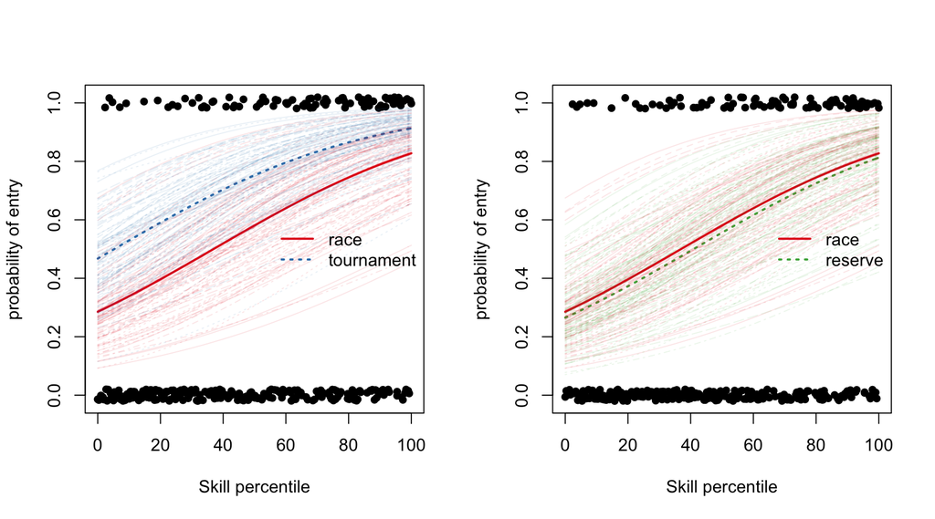

### Large rooms

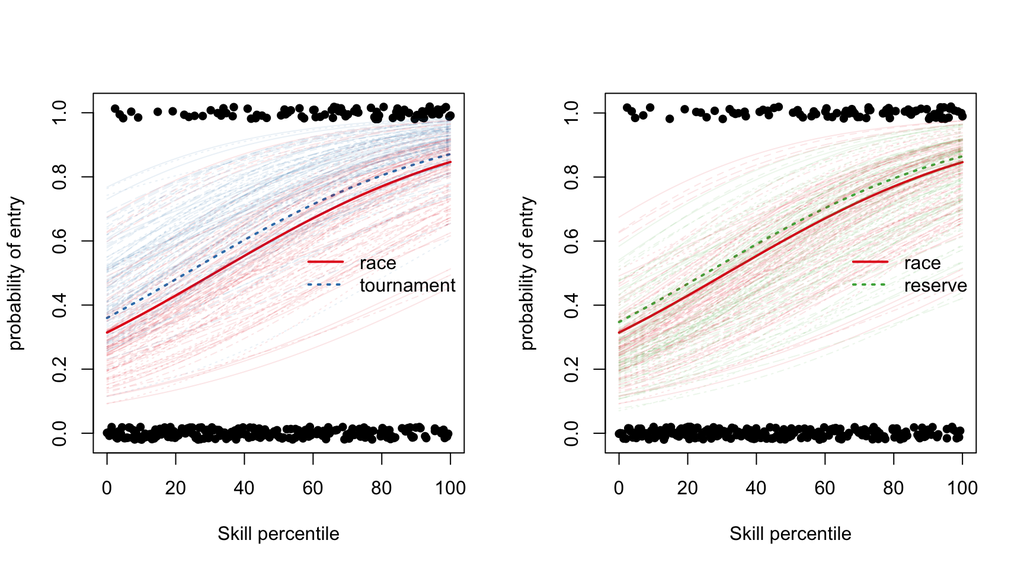

# Appendix

## Diagnostic plots for logistic models

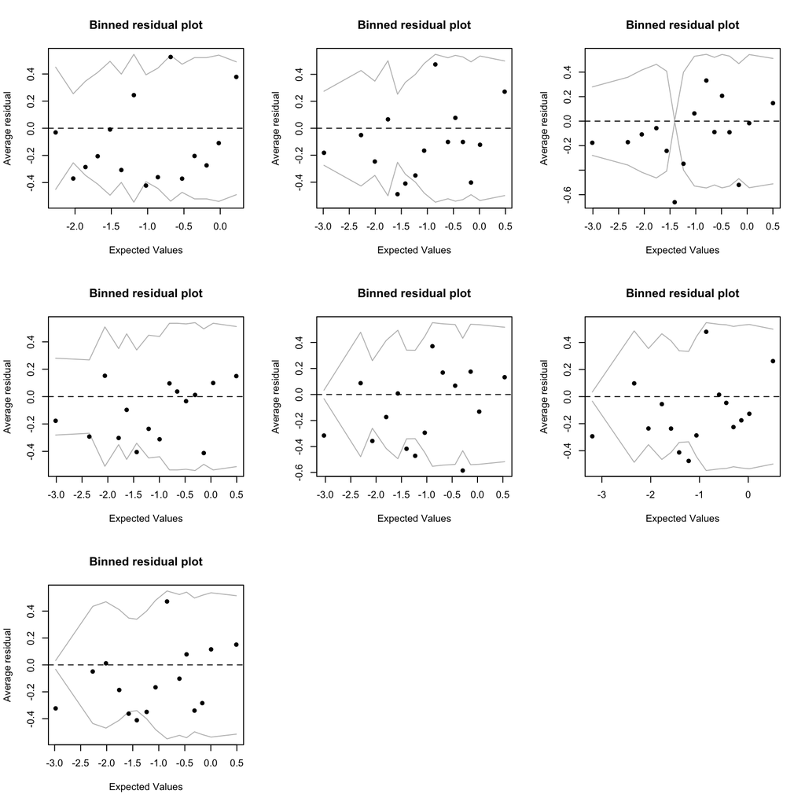

```r
par(mfrow = c(3,3))
mod <- binom.entry
for (i in 1:length(mod)) {
  pred <- predict(mod[[i]])
  res <- resid(mod[[i]])
  arm::binnedplot(pred, res, nclass = 15)
}
```